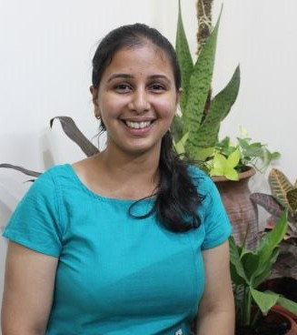

# Adithi R. Upadhya

## Bio

Adithi R. Upadhya is a Geoinformatics graduate with an interdisciplinary research background. Enthusiastic R, C++ and Python developer. Worked on mobile monitoring of air quality in Bangalore. Current role: Geospatial Data Analyst at ILK Labs. Interested in machine learning, artificial intelligence, environmental issues and spatial science.

## Education

**Bharati Vidyapeeth Institute of Environment Education and Research** | Pune, India

M.Sc Geoinformatics | 2016 - 2018

**Sri Sathya Sai Institute of Higher Learning** | Anantapur, India

B.Sc in Physics | 2013 - 2016

## Experience

[**ILK Labs**](https://www.ilklabs.com/about-us/team) | Geospatial Data Analyst | October 2018 - Present

**Sri Ramachandra Institute of Higher Education and Research** | Analyst and Instructor | 2021 - Present

**Asian Nature Conservation Foundation** | GIS Consultant | 2020 - 2021

[**ILK Labs, New York Times**](https://www.nytimes.com/interactive/2020/12/17/world/asia/india-pollution-inequality.html?smtyp=cur&smid=tw-nytimes&s=08) | Consultant | 2019

**National Center for Polar and Ocean Research** | Intern | 2018

**Bharati Vidyapeeth Institute of Environment Education and Research, WAi Technologies** | Master Thesis and Intern | 2017

## Volunteer and Non-Profit Experience

Peer reviewer for [**Journal of Open-Source Software**](https://joss.theoj.org/papers/reviewed_by/@adithirgis)

Moderating and facilitating Incubator on Strategies to build a strong Asian R community at [**useR! 2021**](https://user2021.r-project.org/join/)

Founder and Co-organiser of [**R-Ladies Bangalore**](https://twitter.com/RLadiesBLR)

Volunteer of [**Bangpypers**](https://bangalore.pythonindia.org/) (Bangalore Python users’ group) and [**PyCon India 2021**](https://in.pycon.org/2021/about/)

Global organising team for Sponsorship, Program and Content team and part of Code of Conduct Response team for the [**useR! 2021**](https://user2021.r-project.org/about/global-team/)

Facilitator of Asian Cohort of [**R4DS book club**](https://twitter.com/R4DScommunity)

Co-hosted a live Q and A session - Teaching for [**rstudio::global(2021)**](https://www.rstudio.com/resources/rstudioglobal-2021/?category_ids=1753-teaching), chair for Keynote at [**useR! 2021**](https://www.youtube.com/watch?v=itIcbhPnAS8)

## Software packages

Built [**polluchek**](https://github.com/adithirgis/pollucheck) | Journal of Open Source Software | 2021

Maintenance of [**ropenaq**](https://github.com/ropensci/ropenaq) | [rOpenSci](https://ropensci.org/) | 2021

Built [**mmaqshiny**](https://github.com/meenakshi-kushwaha/mmaqshiny) | CRAN, Journal of Open Source Software | 2020

## Awards and Honors

[rstudio::global(2021)](https://www.rstudio.com/conference/) Diversity Scholar | 2021

[R@IISA](http://r-iisa2019.rbind.io/) Conference Travel Award | 2019

Primer in Methods and Ecological Research ([PRiMER](https://gubbilabs.in/courses/media-gallery/detail/8/62)) Sponsored by ILK Labs | 2019

For undergraduate degree at Sri Sathya Sai Institute of Higher Learning received Gold Medal | 2016

Indian Academy of Sciences [Summer Research Fellowship Program](https://webjapps.ias.ac.in/fellowship2021/lists/result.jsp) | 2015